# Case Study - Adverse Events vs Country

Fred (Deyu) Sun

8/21/2020

## R Packages used in this analysis

```r
library(httr)
library(jsonlite)
library(knitr)
library(kableExtra)
library(dplyr)
```

# Problem Statement

The database of FDA adverse event report systems (FAERS) contains a list of the patient reactions and the country from where a report comes. The research question of this study is, are different adverse events reported in different countries? In other words, the association between adverse event types and countries is to be tested.

# Methods

The variables to be tested are categorical. In statistics, contingency tables are used to summarize the relationship between categorical variables. A chi-square test can then be conducted on contingency tables to test whether or not an association exists between variables. When the evidence of association is found, pairwise two-sample proportion tests can be used to compare the different proportions of a specific adverse event type between any given two countries.

The data used in this study is the drug event endpoint and ranges from the first quarter of 2004 to the second quarter of 2020.

# Results

## Data Exploration: Countries Reporting to the FAERS

```r
# A function to query FAERS database via openFDA API
GetResponse = function(URL) {
  response = GET(URL)
  # Request failed if status code != 200
  if(response$status_code != 200)
    return(NULL)
  response = content(response, as = "text")
  response = fromJSON(response)
  response = response$results
  return(response)
}

Country_table = GetResponse("https://api.fda.gov/drug/event.json?api_key=ts0BKaDMfrjs2adslwvDJWIM8fGcngovS1QX5jD4&count=occurcountry.exact&limit=1000")
kable(Country_table, format = "html", row.names = FALSE) %>% kable_styling() %>% scroll_box(width = "75%", height = "380px")
```

| term | count |
| --- | --- |
| US | 6388630 |
| GB | 308790 |
| CA | 281830 |
| JP | 265394 |
| FR | 261943 |
| DE | 199092 |
| IT | 143542 |
| BR | 95057 |
| ES | 75646 |
| AU | 67816 |
| CN | 64952 |
| NL | 59882 |
| CO | 38452 |
| IN | 35146 |
| SE | 32531 |
| AR | 27101 |
| TR | 26475 |
| CH | 24406 |
| PL | 23063 |
| BE | 22473 |
| PT | 21921 |
| KR | 20593 |
| MX | 18987 |
| GR | 18205 |
| TW | 18006 |
| IL | 16255 |
| AT | 16025 |
| DK | 15976 |
| IE | 15854 |
| RU | 14710 |

[output cut: 205 more lines]

```r
# Percentage of event reports coming from the top 10 countries
top10countries = Country_table$term[1:10]
cat('Percentage of event reports coming from the top 10 countries is:', paste(round(sum(Country_table$count[1:10])/sum(Country_table$count)*100,2),'%', sep=''))
```

```
## Percentage of event reports coming from the top 10 countries is: 91.54%
```

Although there are 235 different country names were retrieved, several top countries submitted most of the reports. The top 10 countries (United States, United Kingdom, Canada, Japan, France, Germany, Italy, Brazil, Spain, and Australia) account for 92% of all adverse events reported. To simplify the analysis, I focused on the top 10 countries.

## Data Exploration: Patient Reactions Reporting to the FAERS

```r
AE_table = GetResponse("https://api.fda.gov/drug/event.json?api_key=ts0BKaDMfrjs2adslwvDJWIM8fGcngovS1QX5jD4&count=patient.reaction.reactionmeddrapt.exact&limit=1000")
kable(AE_table, format = "html", row.names = FALSE) %>% kable_styling() %>% scroll_box(width = "75%", height = "380px")
```

| term | count |
| --- | --- |
| DRUG INEFFECTIVE | 769031 |
| NAUSEA | 497322 |
| DEATH | 489304 |
| FATIGUE | 451768 |
| HEADACHE | 398461 |
| DIARRHOEA | 370599 |
| DYSPNOEA | 354296 |
| OFF LABEL USE | 341382 |
| PAIN | 336666 |
| DIZZINESS | 320681 |
| MALAISE | 300641 |
| VOMITING | 295437 |
| RASH | 248235 |
| ASTHENIA | 237468 |
| ARTHRALGIA | 230006 |
| PYREXIA | 217727 |
| FALL | 210342 |
| PRURITUS | 198681 |
| PNEUMONIA | 197235 |
| PAIN IN EXTREMITY | 194371 |
| ANXIETY | 184039 |
| INSOMNIA | 178866 |
| INJECTION SITE PAIN | 172081 |
| WEIGHT DECREASED | 170375 |
| DRUG DOSE OMISSION | 166250 |
| FEELING ABNORMAL | 162286 |
| DEPRESSION | 160335 |
| COUGH | 159095 |
| BACK PAIN | 148411 |
| CONDITION AGGRAVATED | 146704 |

[output cut: 970 more lines]

The count queries returns up to 1000 results, and I cannot paginate through “count” queries with the “skip” parameter. So only the top 1000 adverse events can be counted. The approach in this study and the codes below can analyze the arbitrary number of adverse events. However, for simplicity, only the top 10 adverse events were chosen for analysis (accounts for 36.56% of all adverse events).

```r
query = paste('https://api.fda.gov/drug/event.json?api_key=ts0BKaDMfrjs2adslwvDJWIM8fGcngovS1QX5jD4&search=(patient.reaction.reactionmeddrapt:"', paste(gsub(' ', '+', AE_table$term[1:10]), collapse = '"+"'), '")&count=occurcountry&limit=1000', sep='')

topN_AE = GetResponse(query)

cat('Prevalence of the top 10 adverse event types is:', paste(round(sum(topN_AE$count[1:10])/sum(Country_table$count)*100,2),'%', sep=''))
```

```
## Prevalence of the top 10 adverse event types is: 36.56%
```

## Contingency Table Creation

The table below is the contingency table, which displays the frequency distribution of the variables (countries and adverse events). Here, I defined the frequency of an adverse event type as the ratio of the reports containing the adverse event type and the total number of reports.

```r
TOP_N_AE = 10 # top N adverse events to be analyzed. Can be set to any arbituary natural number.

# Create a contigency table of country x AE
mAEbyCountry = matrix(rep(NA, 10*(1+TOP_N_AE)), ncol=10)
row.names(mAEbyCountry) = c(AE_table$term[1:10], 'OTHERS')
colnames(mAEbyCountry) = top10countries

## Count top N adverse events for each country
for (j in 1:10) {
  for (i in 1:TOP_N_AE) {
    query = paste("https://api.fda.gov/drug/event.json?api_key=ts0BKaDMfrjs2adslwvDJWIM8fGcngovS1QX5jD4&search=(occurcountry:", top10countries[j], ')+AND+(patient.reaction.reactionmeddrapt:"', gsub(' ', '+', AE_table$term[i]),'")&count=patient.reaction.reactionmeddrapt.exact&limit=1', sep='')
    result = GetResponse(query)
    if(!is.null(result)) {
      mAEbyCountry[i,j] = result$count[1]
    }
  }
}

## Count "OTHERS" adverse events for each country
for(j in 1:10) {
  mAEbyCountry[(TOP_N_AE+1),j] = sum(Country_table$count[j]) - sum(mAEbyCountry[1:TOP_N_AE,j])
}

kable(mAEbyCountry, format = "html", caption="Contingency Table", row.names = TRUE) %>% kable_styling() %>% scroll_box(width = "100%", height = "450px")
```

Contingency Table

|  | US | GB | CA | JP | FR | DE | IT | BR | ES | AU |
| --- | --- | --- | --- | --- | --- | --- | --- | --- | --- | --- |
| DRUG INEFFECTIVE | 512062 | 6556 | 42892 | 4918 | 4995 | 4685 | 4915 | 7474 | 2356 | 2317 |
| NAUSEA | 250390 | 11751 | 18936 | 6132 | 6970 | 8252 | 4241 | 3266 | 1433 | 2060 |
| DEATH | 236503 | 18073 | 19710 | 6678 | 4839 | 5848 | 2093 | 5606 | 1839 | 4987 |
| FATIGUE | 256828 | 12868 | 22126 | 1776 | 9855 | 7611 | 1361 | 3787 | 1089 | 1879 |
| HEADACHE | 215990 | 10737 | 14759 | 2282 | 7664 | 4620 | 2554 | 4234 | 1089 | 1490 |
| DIARRHOEA | 193547 | 10182 | 15409 | 7249 | 8558 | 6766 | 3976 | 3011 | 2332 | 1661 |
| DYSPNOEA | 159300 | 12560 | 17142 | 3073 | 6387 | 7912 | 5479 | 4790 | 1417 | 1806 |
| OFF LABEL USE | 240568 | 5779 | 19018 | 6776 | 9351 | 5887 | 4256 | 4241 | 2923 | 1868 |
| PAIN | 187055 | 6459 | 19463 | 1843 | 4781 | 3468 | 2496 | 6574 | 869 | 1303 |
| DIZZINESS | 154477 | 11374 | 10463 | 2899 | 3455 | 6828 | 1079 | 3326 | 1357 | 1281 |
| OTHERS | 3981910 | 202451 | 81912 | 221768 | 195088 | 137215 | 111092 | 48748 | 58942 | 47164 |

We can also visualize the frequency distribution of adverse events in each of the countries. From the pie charts below, we can see different patterns. In Canada, the top 10 adverse events account for more than two-thirds of all reported incidents, while in Japan and Spain, the same adverse events account for only a small proportion (less than 25%).

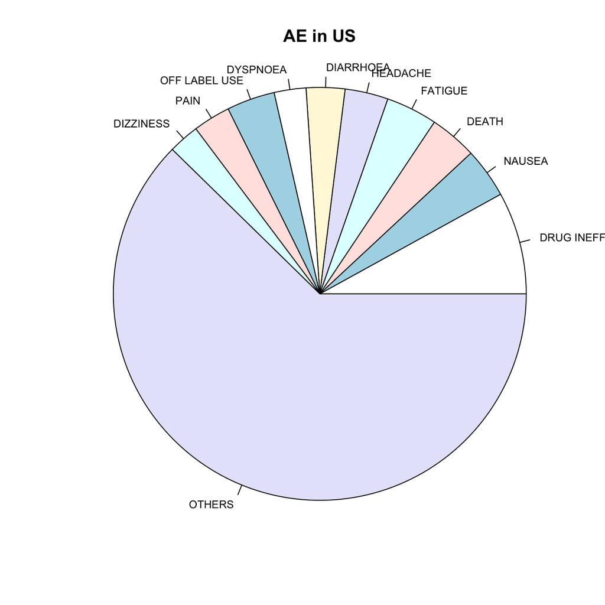

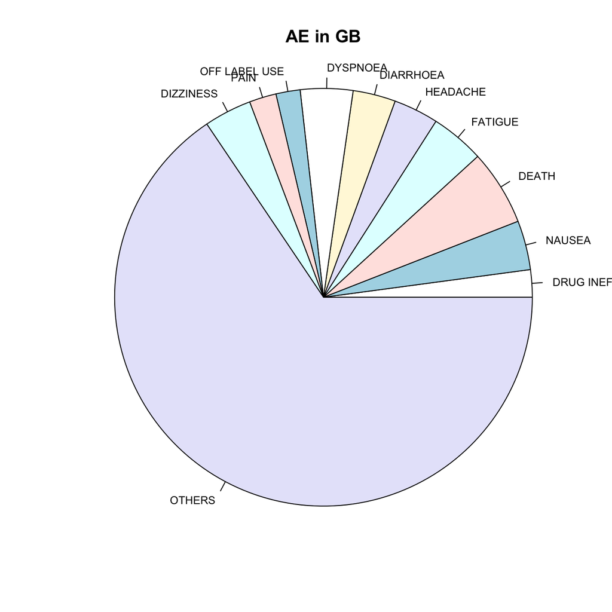

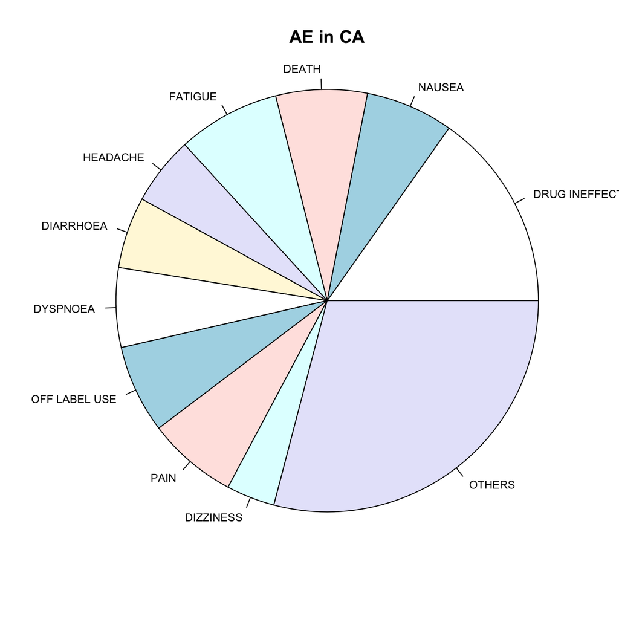

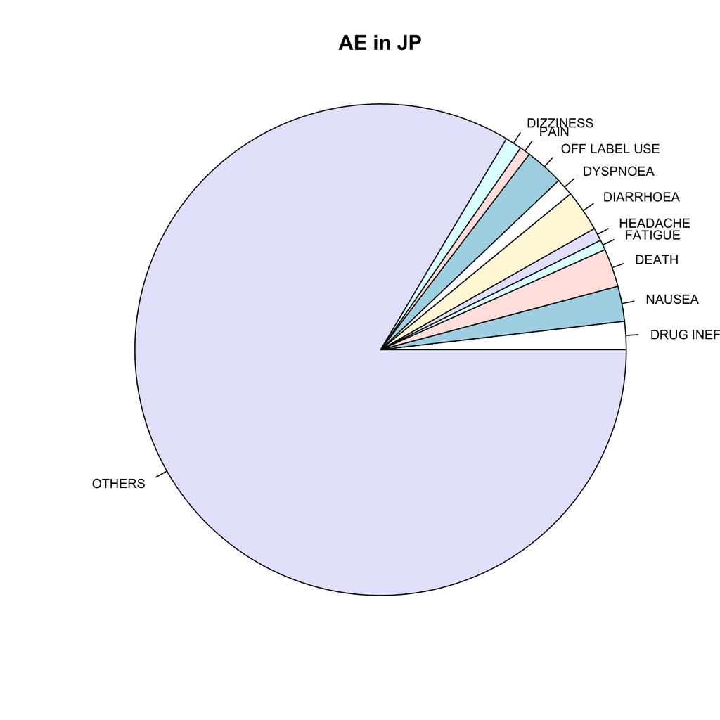

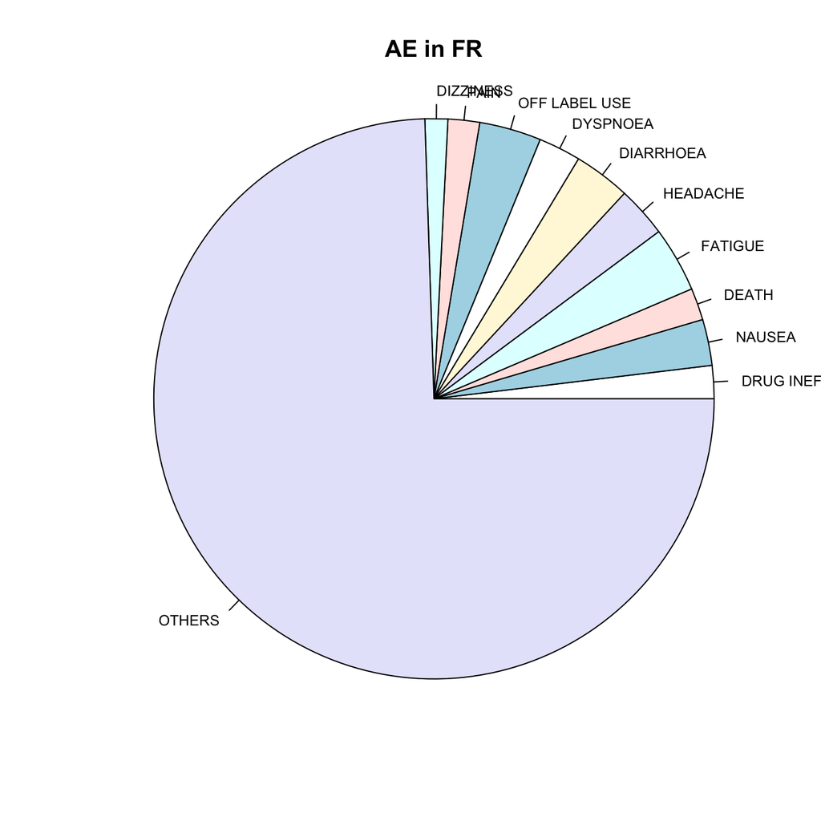

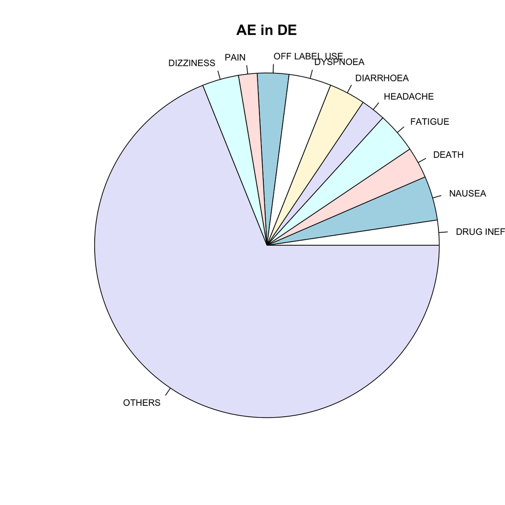

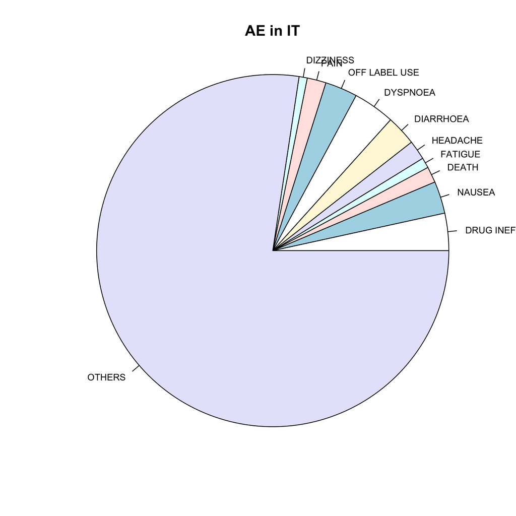

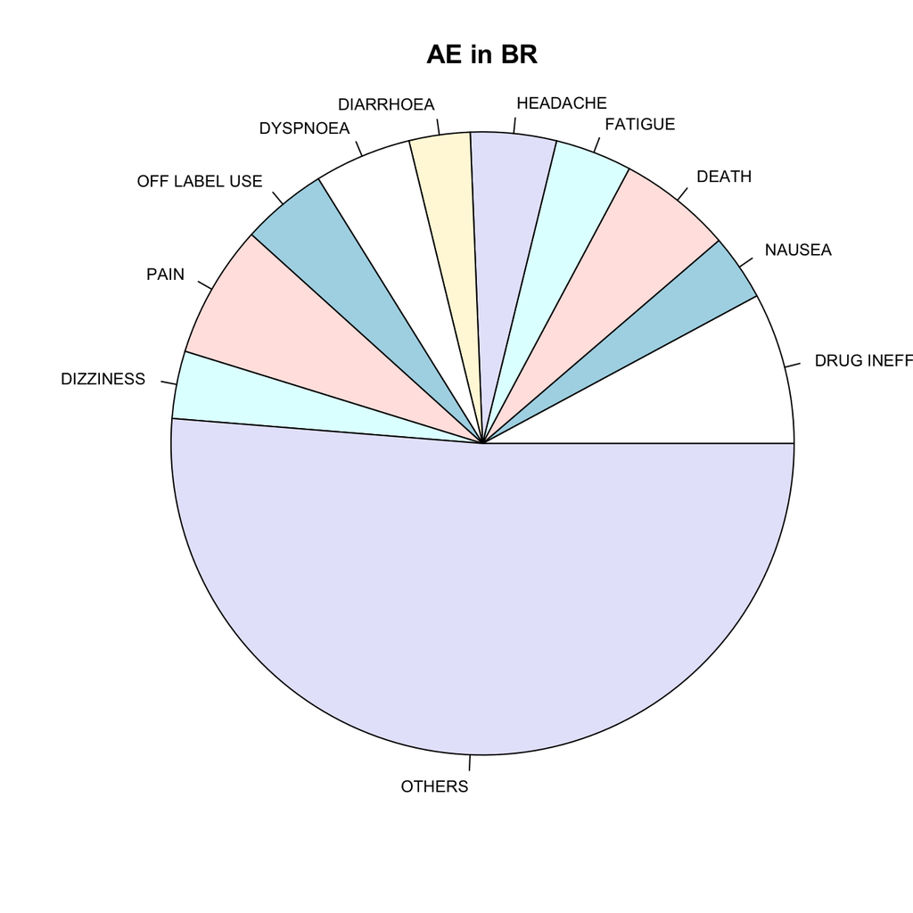

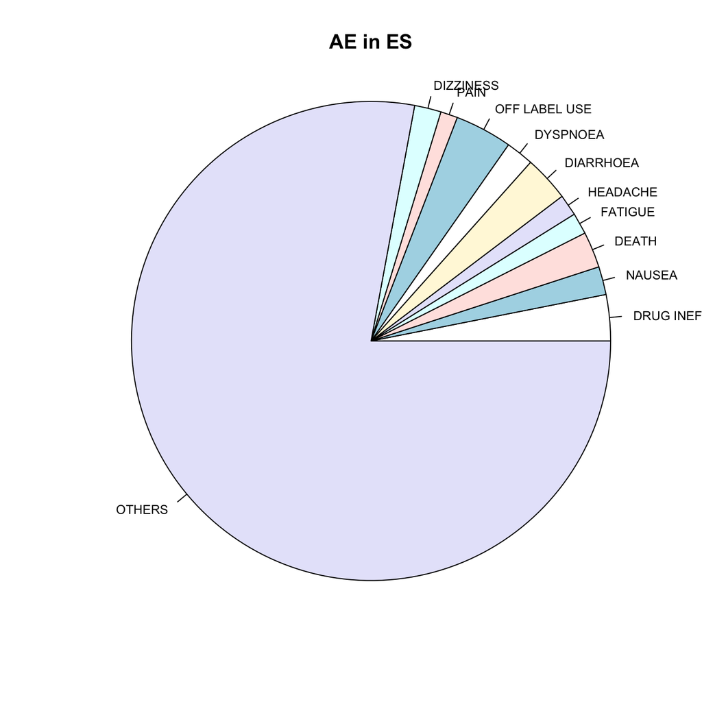

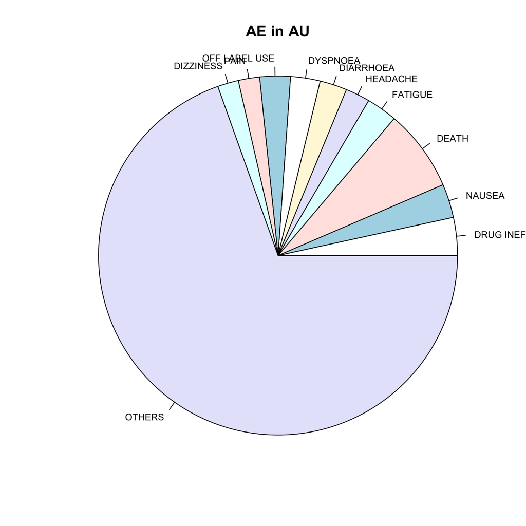

output

```r
#par(mfrow = c(4, 3))
for (j in 1:10) {
 pie(mAEbyCountry[,j], radius=1, cex=0.75, main=paste("AE in", top10countries[j]))
}
```

It is worth noting that since adverse events may coexist in one report and in the pie charts I treated top 10 types as disjoint sets, in fact, the total frequency of the top 10 types of adverse events is slightly overestimated while the total frequency of the other types is underestimated. The real total frequency of the top 10 types is 36.51%, while the overestimated total frequency is 37.11%. However, the frequency of each of the top 10 types is accurate.

```r
query = paste('https://api.fda.gov/drug/event.json?api_key=ts0BKaDMfrjs2adslwvDJWIM8fGcngovS1QX5jD4&search=(patient.reaction.reactionmeddrapt:"', paste(gsub(' ', '+', AE_table$term[1:10]), collapse = '"+"'), '")', '+AND+(occurcountry:"', paste(top10countries, collapse = '"+"'), '")&count=occurcountry&limit=1000', sep='')

topN_AE = GetResponse(query)

cat('Real prevalence of the top 10 adverse event types in the top 10 countries is:', paste(round(sum(topN_AE$count[1:10])/sum(Country_table$count)*100,2),'%\n', sep=''))
```

```
## Real prevalence of the top 10 adverse event types in the top 10 countries is: 36.51%
```

```r
cat('The overestimated prevalence of the top 10 adverse event types in the top 10 countries is:', paste(round(sum(mAEbyCountry[1:10,])/sum(Country_table$count[1:10])*100,2),'%\n', sep=''))
```

```
## The overestimated prevalence of the top 10 adverse event types in the top 10 countries is: 37.11%
```

## Statistical Tests

A chi-square test of the contingency table indicates a significant association between adverse events countries (p-value<2.2e-16).

```r
# chi-squared test of association: countries vs adverse events
chisq.test(mAEbyCountry)
```

```
##
##  Pearson's Chi-squared test
##
## data:  mAEbyCountry
## X-squared = 304460, df = 90, p-value < 2.2e-16
```

We can compare the difference in the distribution of a specific adverse event by pairwise proportion test. Take death, for example. From the p-value table, we can see except for Brazil and Britain, Japan and Spain, all other pairs of comparisons are significant. P-values shown below are adjusted by Bonferroni correction.

```r
# pairwise proportion test of "death" adverse event
ls.test = pairwise.prop.test(mAEbyCountry["DEATH",], apply(mAEbyCountry, 2, sum), "bonferroni")
kable(ls.test$p.value, format = "html", caption="p-values of pairwise proportion test", row.names = TRUE) %>% kable_styling() %>% scroll_box(width = "100%", height = "400px")
```

p-values of pairwise proportion test

|  | US | GB | CA | JP | FR | DE | IT | BR | ES |
| --- | --- | --- | --- | --- | --- | --- | --- | --- | --- |
| GB | 0 | NA | NA | NA | NA | NA | NA | NA | NA |
| CA | 0 | 0 | NA | NA | NA | NA | NA | NA | NA |
| JP | 0 | 0 | 0.0000000 | NA | NA | NA | NA | NA | NA |
| FR | 0 | 0 | 0.0000000 | 0 | NA | NA | NA | NA | NA |
| DE | 0 | 0 | 0.0000000 | 0 | 0 | NA | NA | NA | NA |
| IT | 0 | 0 | 0.0000000 | 0 | 0 | 0 | NA | NA | NA |
| BR | 0 | 1 | 0.0000000 | 0 | 0 | 0 | 0 | NA | NA |
| ES | 0 | 0 | 0.0000000 | 1 | 0 | 0 | 0 | 0 | NA |
| AU | 0 | 0 | 0.0470363 | 0 | 0 | 0 | 0 | 0 | 0 |

The bar plots display the distribution of the death events in each country. We can see that Australia has significantly higher death adverse events rate (7.4%) than in other countries.

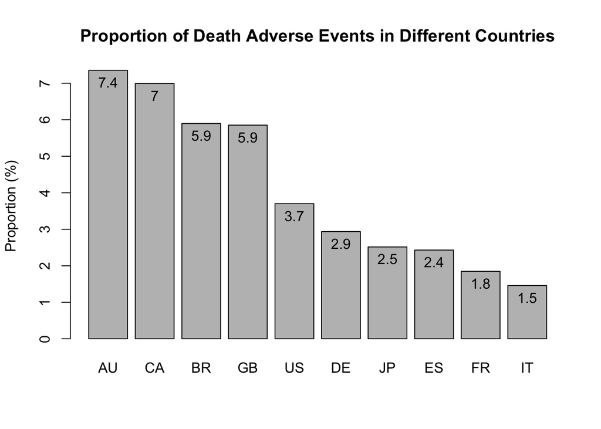

```r
DeathProportions = sort(mAEbyCountry["DEATH",]/apply(mAEbyCountry, 2, sum)*100, decreasing = T)
bp = barplot(DeathProportions, main = "Proportion of Death Adverse Events in Different Countries", ylab="Proportion (%)")
text(bp, DeathProportions, round(DeathProportions,1), cex=1, pos=1)
```

# Discussion

The analysis in this study helps identify different distribution patterns of adverse events in different countries and raise awareness about the adverse events of higher prevalence. E.g., from the barplot above, we can see Australia, Canada, Brazil, and Britain have a much higher proportion of death adverse events. A further study can be conducted to identify the root cause and mitigate such adverse events. In addition to comparisons between countries, we can also compare different categories of countries, like developed and developing countries, or states in various regions such as Africa and North America. The ultimate goal of such comparisons is to understand the magnitude of the problem and underlying factors, which represents the first step towards improvement.

The solution proposed here can also be applied to answer the second question: “what are the different adverse events associated with different disease areas.” To do that, we need to construct a contingency table for adverse event types and disease types to be treated. Then similar statistical tests can be used to determine if adverse events and disease areas are associated.

There are some limitations to this study. First, FAERS data is not entirely validated, and adverse events are underreported. If the underreporting is not completely random, then our analysis may be biased. E.g., the lower death event rates in Italy (1.5%) might be caused by underreporting. Second, for simplicity, I only chose the top 10 adverse events to analyze and find out the evidence of significant association. Otherwise, if we cannot reject the null hypothesis by just looking at the top 10 events, since there are more events in the “others” category (63% of all events), we need to include more types of adverse events to decide whether to accept or reject the null hypothesis.

# Conclusion

In this case study, a contingency table and chi-square test are used to test the hypothesis about the association between adverse events and countries. According to the results, different adverse events are reported in different countries (p-value<2.2e-16). Take death adverse events, for example. I showed how adverse events are distributed differently in different countries.